# Ford GoBike Trip Data Exploration

## by Nacer KROUDIR

## Investigation Overview

The focus of the presentation is on the duration of bike trips as a primary variable of interest and is presented in two plots. The analysis also looks at the geographical aspect of the bike trips with a bar chart of the most active bike stations and a heatmap of the San Fransisco Bay area using the coordinates of start and end stations. Additionally, a pie chart is created to show the demographic distribution of the bike users' gender. Lastly, a scatter plot of trip duration versus age is presented grouped by user type to show the relationship between the three variables.

## Dataset Overview

This data set includes information about individual rides made by Ford GoBike system. This data file corresponds to February 2019 in San Francisco Bay area.

## Distribution of Duration in Minutes

`duration_minutes` is the duration taken on the trip by bike. The distrubtion is highly positively skewed with 95% of trips taking less than 30 minutes. There are durations as long as 1424 minutes. I cut down the x-axis to show upto 60 minutes only so that the distribution is more visible and clear. Keep in mind that there are very few long trip durations that aren't visible.

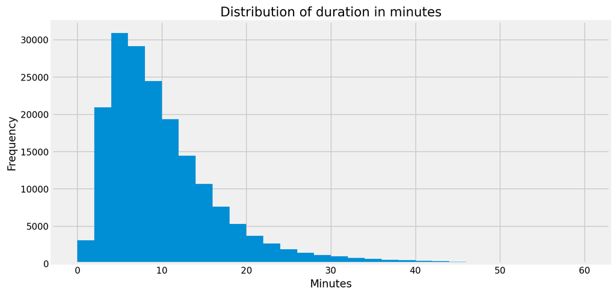

## Most Active Bike Stations

The following bar chart shows the top 10 most active bike stations. The activity of each station is calculated by calculating its frequency as a start station and as an end station.

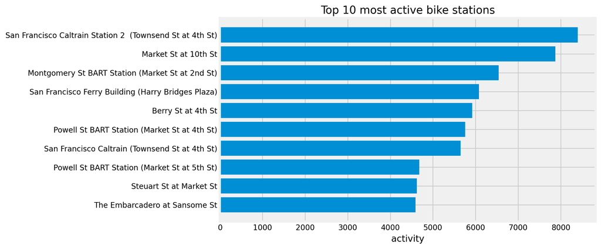

## Distribution of Member Gender

For the distribution of gender, Male represent three quarters of the users of Ford GoBike system; While Female represent 23.3% as seen in the next pie chart.

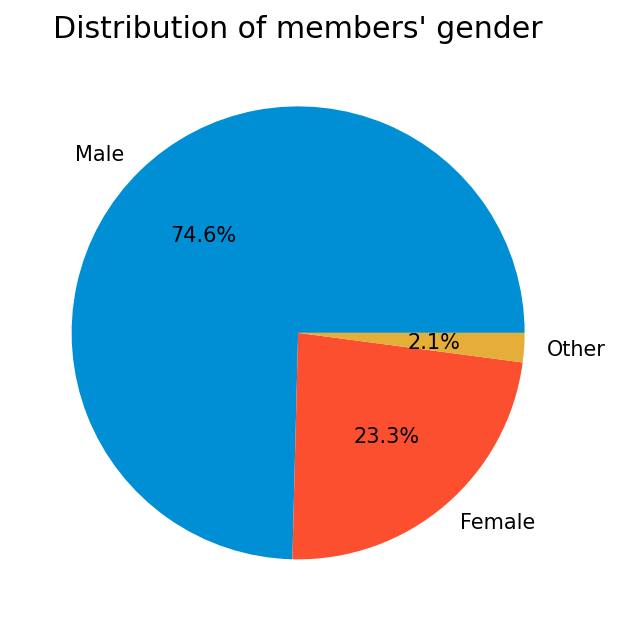

## Station Coordinates on the Map and Their Activity

The next map represents the three areas of activity that are:

- San Fransisco
- Oakland
- San Jose

The heatmap could be filtered start stations activity, end stations activity, or the total activity by using the layer control panel on the top right corner.

Make this Notebook Trusted to load map: File -> Trust Notebook

[interactive chart not shown]

## Duration by Age and User Type

From the next scatter plot of trip duration vs age grouped by user type, we see how age is concentrated between 20 and 40 years old. Also, the duration is mostly less than 30 minutes confirming the previous histogram. For the user type, it has no relationship with the duration of the trip and the age as both user types are distributed through the whole scatter plot.

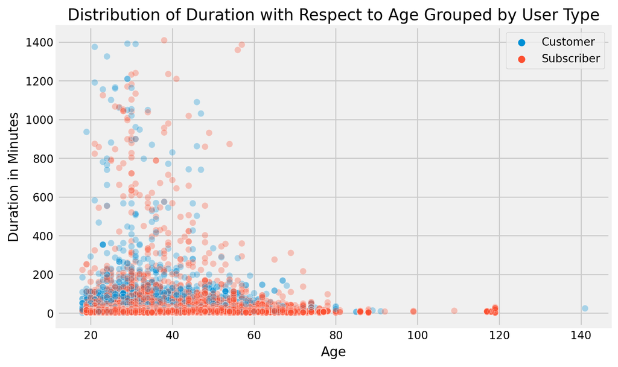